# Reproducible Research: Course Project 2

Paul Skomsvold

May 15, 2016

## The economic and public health consequences of severe weather events in the United States: 1950 - 2011

## Synopsis

Storms and other severe weather events can cause both public health and economic problems for communities and municipalities. Many severe events can result in fatalities, injuries, and property damage, and preventing such outcomes to the extent possible is a key concern.

This report uses data from the U.S. National Oceanic and Atmospheric Administration’s (NOAA) storm database to determine public health and economic consequences of severe weather events in the United States to answer the following questions:

- Which types of weather events are most harmful with respect to public health?
- Which types of weather events have the greatest economic consequences?

Public health impact was measured as the total number of injuries and fatalities associated with each type of weather event from years 1950 to 2011. Economic impact was was measured as the sum of all property damage and crop damage associated with each type of weather event from 1950 to 2011. In this report, public health consequences were reported only for 10 weather events with the highest numbers of fatalities/injuries. Economic consequences were reported only for 5 weather events with the greatest amount of total damage (property and crop combined).

## About the data

The NOAA’s storm database provides information on the characteristics and location of major storms and weather events in the United States from 1950 to 2011, as well as information on injuries, fatalities, and economic damage associated with these events. Data come from the National Weather Service, who receive information from a variety of sources including emergency management professionals, law enforcement officials, the insurance industry, damage surveys, and the general public. Results from the NOAA’s storm database should be interpreted with caution as data come from disparate sources and have not all been verified by the National Weather Service.

Additional information about the data is available from the [National Weather Service](https://d396qusza40orc.cloudfront.net/repdata%2Fpeer2_doc%2Fpd01016005curr.pdf)

The following variables were used in this analysis:

- EVTYPE: Weather event type
- FATALITIES: The number of fatalities caused by a weather event
- INJURIES: The number of injuries caused by a weather event
- PROPDMG: Monetary value of property damage caused by a weather event
- PROPDMGEXP: Exponent to be applied to the value of PROPDMG
- CROPDMG: Monetary value of crop damage caused by a weather event
- CROPDMGEXP: Exponent to be applied to the value of CROPDMG

## Load packages

This report utilized the following add-on packages in R: **knitr**, **ggplot2**, and **reshape2**

```r
library(knitr)
library(ggplot2)
library(reshape2)
```

## Download data

The data used in this report were downloaded on Sunday, May 15 through the R Studio interface.

```r
download.file("https://d396qusza40orc.cloudfront.net/repdata%2Fdata%2FStormData.csv.bz2", "repdata_Fdata_StormData.csv.bz2")
```

Data can also be downloaded from the following link: [Storm Data](https://d396qusza40orc.cloudfront.net/repdata%2Fdata%2FStormData.csv.bz2)

## Data processing

Data were loaded into R Studio using read.csv() and bzfile().

```r
data <- read.csv(bzfile("repdata_Fdata_StormData.csv.bz2"))
```

Basic information about the data:

```r
dim(data)
```

```
## [1] 902297     37
```

```r
head(data)
```

```
##   STATE__           BGN_DATE BGN_TIME TIME_ZONE COUNTY COUNTYNAME STATE
## 1       1  4/18/1950 0:00:00     0130       CST     97     MOBILE    AL
## 2       1  4/18/1950 0:00:00     0145       CST      3    BALDWIN    AL
## 3       1  2/20/1951 0:00:00     1600       CST     57    FAYETTE    AL
## 4       1   6/8/1951 0:00:00     0900       CST     89    MADISON    AL
## 5       1 11/15/1951 0:00:00     1500       CST     43    CULLMAN    AL
## 6       1 11/15/1951 0:00:00     2000       CST     77 LAUDERDALE    AL
##    EVTYPE BGN_RANGE BGN_AZI BGN_LOCATI END_DATE END_TIME COUNTY_END
## 1 TORNADO         0                                               0
## 2 TORNADO         0                                               0
## 3 TORNADO         0                                               0
## 4 TORNADO         0                                               0
## 5 TORNADO         0                                               0
## 6 TORNADO         0                                               0
##   COUNTYENDN END_RANGE END_AZI END_LOCATI LENGTH WIDTH F MAG FATALITIES
```

[output cut: 20 more lines]

```r
str(data)
```

```
## 'data.frame':    902297 obs. of  37 variables:
##  $ STATE__   : num  1 1 1 1 1 1 1 1 1 1 ...
##  $ BGN_DATE  : Factor w/ 16335 levels "1/1/1966 0:00:00",..: 6523 6523 4242 11116 2224 2224 2260 383 3980 3980 ...
##  $ BGN_TIME  : Factor w/ 3608 levels "00:00:00 AM",..: 272 287 2705 1683 2584 3186 242 1683 3186 3186 ...
##  $ TIME_ZONE : Factor w/ 22 levels "ADT","AKS","AST",..: 7 7 7 7 7 7 7 7 7 7 ...
##  $ COUNTY    : num  97 3 57 89 43 77 9 123 125 57 ...
##  $ COUNTYNAME: Factor w/ 29601 levels "","5NM E OF MACKINAC BRIDGE TO PRESQUE ISLE LT MI",..: 13513 1873 4598 10592 4372 10094 1973 23873 24418 4598 ...
##  $ STATE     : Factor w/ 72 levels "AK","AL","AM",..: 2 2 2 2 2 2 2 2 2 2 ...
##  $ EVTYPE    : Factor w/ 985 levels "   HIGH SURF ADVISORY",..: 834 834 834 834 834 834 834 834 834 834 ...
##  $ BGN_RANGE : num  0 0 0 0 0 0 0 0 0 0 ...
##  $ BGN_AZI   : Factor w/ 35 levels "","  N"," NW",..: 1 1 1 1 1 1 1 1 1 1 ...
##  $ BGN_LOCATI: Factor w/ 54429 levels ""," Christiansburg",..: 1 1 1 1 1 1 1 1 1 1 ...
##  $ END_DATE  : Factor w/ 6663 levels "","1/1/1993 0:00:00",..: 1 1 1 1 1 1 1 1 1 1 ...
##  $ END_TIME  : Factor w/ 3647 levels ""," 0900CST",..: 1 1 1 1 1 1 1 1 1 1 ...
##  $ COUNTY_END: num  0 0 0 0 0 0 0 0 0 0 ...
```

[output cut: 23 more lines]

```r
summary(data)
```

```
##     STATE__                  BGN_DATE             BGN_TIME
##  Min.   : 1.0   5/25/2011 0:00:00:  1202   12:00:00 AM: 10163
##  1st Qu.:19.0   4/27/2011 0:00:00:  1193   06:00:00 PM:  7350
##  Median :30.0   6/9/2011 0:00:00 :  1030   04:00:00 PM:  7261
##  Mean   :31.2   5/30/2004 0:00:00:  1016   05:00:00 PM:  6891
##  3rd Qu.:45.0   4/4/2011 0:00:00 :  1009   12:00:00 PM:  6703
##  Max.   :95.0   4/2/2006 0:00:00 :   981   03:00:00 PM:  6700
##                 (Other)          :895866   (Other)    :857229
##    TIME_ZONE          COUNTY           COUNTYNAME         STATE
##  CST    :547493   Min.   :  0.0   JEFFERSON :  7840   TX     : 83728
##  EST    :245558   1st Qu.: 31.0   WASHINGTON:  7603   KS     : 53440
##  MST    : 68390   Median : 75.0   JACKSON   :  6660   OK     : 46802
##  PST    : 28302   Mean   :100.6   FRANKLIN  :  6256   MO     : 35648
##  AST    :  6360   3rd Qu.:131.0   LINCOLN   :  5937   IA     : 31069
##  HST    :  2563   Max.   :873.0   MADISON   :  5632   NE     : 30271
##  (Other):  3631                   (Other)   :862369   (Other):621339
##                EVTYPE         BGN_RANGE           BGN_AZI
##  HAIL             :288661   Min.   :   0.000          :547332
##  TSTM WIND        :219940   1st Qu.:   0.000   N      : 86752
##  THUNDERSTORM WIND: 82563   Median :   0.000   W      : 38446
##  TORNADO          : 60652   Mean   :   1.484   S      : 37558
##  FLASH FLOOD      : 54277   3rd Qu.:   1.000   E      : 33178
##  FLOOD            : 25326   Max.   :3749.000   NW     : 24041
##  (Other)          :170878                      (Other):134990
##          BGN_LOCATI                  END_DATE             END_TIME
##               :287743                    :243411              :238978
##  COUNTYWIDE   : 19680   4/27/2011 0:00:00:  1214   06:00:00 PM:  9802
##  Countywide   :   993   5/25/2011 0:00:00:  1196   05:00:00 PM:  8314
##  SPRINGFIELD  :   843   6/9/2011 0:00:00 :  1021   04:00:00 PM:  8104
##  SOUTH PORTION:   810   4/4/2011 0:00:00 :  1007   12:00:00 PM:  7483
##  NORTH PORTION:   784   5/30/2004 0:00:00:   998   11:59:00 PM:  7184
##  (Other)      :591444   (Other)          :653450   (Other)    :622432
##    COUNTY_END COUNTYENDN       END_RANGE           END_AZI
##  Min.   :0    Mode:logical   Min.   :  0.0000          :724837
##  1st Qu.:0    NA's:902297    1st Qu.:  0.0000   N      : 28082
##  Median :0                   Median :  0.0000   S      : 22510
##  Mean   :0                   Mean   :  0.9862   W      : 20119
##  3rd Qu.:0                   3rd Qu.:  0.0000   E      : 20047
##  Max.   :0                   Max.   :925.0000   NE     : 14606
##                                                 (Other): 72096
```

[output cut: 41 more lines]

```
##  Min.   :   0   Min.   :-14451   Min.   :   0   Min.   :-14455
##  1st Qu.:2802   1st Qu.:  7247   1st Qu.:   0   1st Qu.:     0
##  Median :3540   Median :  8707   Median :   0   Median :     0
##  Mean   :2875   Mean   :  6940   Mean   :1452   Mean   :  3509
##  3rd Qu.:4019   3rd Qu.:  9605   3rd Qu.:3549   3rd Qu.:  8735
##  Max.   :9706   Max.   : 17124   Max.   :9706   Max.   :106220
##  NA's   :47                      NA's   :40
##                                            REMARKS           REFNUM
##                                                :287433   Min.   :     1
##                                                : 24013   1st Qu.:225575
##  Trees down.\n                                 :  1110   Median :451149
##  Several trees were blown down.\n              :   568   Mean   :451149
##  Trees were downed.\n                          :   446   3rd Qu.:676723
##  Large trees and power lines were blown down.\n:   432   Max.   :902297
##  (Other)                                       :588295
```

The original data file contained 985 individual weather event categories to classify the 902,297 events in the data file. A significant amount of time was dedicated to cleaning storm event type categories and aggregating them into the 48 categories listed on page 6 of the [Storm Data Codebook](https://d396qusza40orc.cloudfront.net/repdata%2Fpeer2_doc%2Fpd01016005curr.pdf)

In order to do this, event types (EVTYPE) were converted to lower case format and grep() and grepl() were used to replace text strings that contained keywords. For example, 108 unique strings containing “tstm” or “thunderstorm” that did not also contain “marine” were reclassified into one category: “thunderstorm wind”. While some misclassification may have occurred, these edits made measures of public health and economic consequences of general weather events clearer than if the original categories were used.

```r
##Convert EVTYPE to lower case format
data$EVTYPE <- tolower(data$EVTYPE)
##Cleanup/normalize EVTYPE
###Avalanche
data[grep("avalance", data$EVTYPE), "EVTYPE"] <- "avalanche"
###Thunderstorm wind
data[grepl("wind", data$EVTYPE) & !grepl("marine", data$EVTYPE) &
       grepl("thunderstorm|tunderstorm|tunderstrom|thunderstrom|thundertsorm", data$EVTYPE),
     "EVTYPE"] <- "thunderstorm wind"
data[grepl("tstm|thunderstorm", data$EVTYPE) & !grepl("marine", data$EVTYPE), "EVTYPE"] <- "thunderstorm wind"
data[grepl("thunderstorm", data$EVTYPE) & grepl("wins|w inds|damage|severe", data$EVTYPE), "EVTYPE"] <- "thunderstorm wind"
data[grep("thunderstormw", data$EVTYPE), "EVTYPE"] <- "thunderstorm wind"
###Blow-out tides
data[grep("blow-out tide", data$EVTYPE), "EVTYPE"] <- "blow-out tides"
###High tides
data[grep("high tide", data$EVTYPE), "EVTYPE"] <- "high tides"
data[grepl("high", data$EVTYPE) & grepl("water|seas", data$EVTYPE), "EVTYPE"] <- "high tides"
###High surf
data[grep("surf|rogue wave", data$EVTYPE), "EVTYPE"] <- "high surf"
data[grepl("high|heavy|rough", data$EVTYPE) & grepl("seas|swells|waves", data$EVTYPE), "EVTYPE"] <- "high surf"
###Blizzard
data[grep("blizzard", data$EVTYPE), "EVTYPE"] <- "blizzard"
###Coastal flood
data[grepl("coastal|beach", data$EVTYPE) & grepl("flood|surge|erosion", data$EVTYPE), "EVTYPE"] <- "coastal flood"
data[grep("beach erosin", data$EVTYPE), "EVTYPE"] <- "coastal flood"
###Coastal storm
data[grep("coastalstorm", data$EVTYPE), "EVTYPE"] <- "coastal storm"
###Freezing fog
data[grepl("fog", data$EVTYPE) & grepl("cold|ice", data$EVTYPE), "EVTYPE"] <- "freezing fog"
###Dense fog
data[grep("patchy dense fog", data$EVTYPE), "EVTYPE"] <- "dense fog"
###Debris flow
data[grep("mud", data$EVTYPE), "EVTYPE"] <- "debris flow"
data[grepl("landslide|landslump|rock slide", data$EVTYPE), "EVTYPE"] <- "debris flow"
###Fog
data[grep("vog", data$EVTYPE), "EVTYPE"] <- "fog"
###Dense smoke
data[grep("smoke", data$EVTYPE), "EVTYPE"] <- "dense smoke"
###Drought
data[grep("drought", data$EVTYPE), "EVTYPE"] <- "drought"
data[grep("unseasonably dry", data$EVTYPE), "EVTYPE"] <- "drought"
data[grepl("dry", data$EVTYPE) & !grepl("microburst", data$EVTYPE), "EVTYPE"] <- "drought"
data[grep("driest month", data$EVTYPE), "EVTYPE"] <- "drought"
###Dust storm
data[grepl("dust", data$EVTYPE) & !grepl("devil|devel", data$EVTYPE),
     "EVTYPE"] <- "dust storm"
###Dust devil
data[grep("dust devel", data$EVTYPE), "EVTYPE"] <- "dust devil"
###Excessive heat
data[grepl("heat", data$EVTYPE) & !grepl("^heat$", data$EVTYPE), "EVTYPE"] <- "excessive heat"
data[grepl("warm", data$EVTYPE) & !grepl("weather", data$EVTYPE), "EVTYPE"] <- "excessive heat"
data[grepl("record warmth|record high", data$EVTYPE), "EVTYPE"] <- "excessive heat"
data[grep("hot", data$EVTYPE), "EVTYPE"] <- "excessive heat"
data[grep("high temperature record", data$EVTYPE), "EVTYPE"] <- "excessive heat"
###Flash flood
data[grep("flash", data$EVTYPE), "EVTYPE"] <- "flash flood"
data[grep("rapidly rising water", data$EVTYPE), "EVTYPE"] <- "flash flood"
###Frost/freeze
data[grep("frost|freeze", data$EVTYPE),
     "EVTYPE"] <- "frost/freeze"
data[grepl("ice|icy", data$EVTYPE) & grepl("black|road|roads|patchy", data$EVTYPE), "EVTYPE"] <- "frost/freeze"
data[grep("^ice$", data$EVTYPE), "EVTYPE"] <- "frost/freeze"
data[grep("freezing drizzle and freezing", data$EVTYPE), "EVTYPE"] <- "frost/freeze"
data[grep("hypothermia|hyperthermia", data$EVTYPE), "EVTYPE"] <- "frost/freeze"
data[grep("record low", data$EVTYPE), "EVTYPE"] <- "frost/freeze"
###Waterspout
data[grep("waterspout|water spout", data$EVTYPE), "EVTYPE"] <- "waterspout"
###Ice storm
data[grep("ice pellets", data$EVTYPE), "EVTYPE"] <- "ice storm"
data[grep("glaze", data$EVTYPE), "EVTYPE"] <- "ice storm"
###Funnel cloud
data[grep("funnel", data$EVTYPE), "EVTYPE"] <- "funnel cloud"
data[grep("wall cloud", data$EVTYPE), "EVTYPE"] <- "funnel cloud"
###Cold/wind chill
data[grep("^cold$", data$EVTYPE), "EVTYPE"] <- "cold/wind chill"
data[grep("^wind chill$", data$EVTYPE), "EVTYPE"] <- "cold/wind chill"
data[grep("^low wind chill$", data$EVTYPE), "EVTYPE"] <- "cold/wind chill"
data[grepl("cold", data$EVTYPE) &
       grepl("air|weather|temperature|temperatures|wet|winds", data$EVTYPE), "EVTYPE"] <- "cold/wind chill"
data[grep("low temperature", data$EVTYPE), "EVTYPE"] <- "cold/wind chill"
###Extreme cold/wind chill
data[grepl("cold", data$EVTYPE) &
       grepl("excessive|extreme|severe|bitter|unusually|extended|prolong|unseasonably|unseasonable|record", data$EVTYPE), "EVTYPE"] <- "extreme cold/wind chill"
data[grepl("cool", data$EVTYPE) &
       grepl("record|low", data$EVTYPE), "EVTYPE"] <- "extreme cold/wind chill"
data[grepl("temp", data$EVTYPE) &
       grepl("record|low|unseasonal", data$EVTYPE), "EVTYPE"] <- "extreme cold/wind chill"
###Heavy snow
data[grepl("snow", data$EVTYPE) &
       grepl("heavy|squall|accumulation|accumulated|squalls|advisory", data$EVTYPE), "EVTYPE"] <- "heavy snow"
 data[grep("snowfall record", data$EVTYPE), "EVTYPE"] <- "heavy snow"
data[grep("snowstorm", data$EVTYPE), "EVTYPE"] <- "heavy snow"
###Sleet
data[grepl("snow", data$EVTYPE) & grepl("rain|sleet|showers|precip", data$EVTYPE), "EVTYPE"] <- "sleet"
data[grep("freezing rain|sleet|freezing drizzle|freezing spray", data$EVTYPE), "EVTYPE"] <- "sleet"
###Winter weather
data[grepl("snow", data$EVTYPE) & !grepl("heavy", data$EVTYPE),
     "EVTYPE"] <- "winter weather"
data[grepl("winter", data$EVTYPE) & !grepl("storm", data$EVTYPE),
     "EVTYPE"] <- "winter weather"
data[grepl("mixed|monthly|normal", data$EVTYPE) & grepl("precip", data$EVTYPE),
     "EVTYPE"] <- "winter weather"
data[grepl("wet", data$EVTYPE) & grepl("month|weather|year|unseasonably|abnormally|cool", data$EVTYPE),
     "EVTYPE"] <- "winter weather"
data[grep("wintry mix", data$EVTYPE), "EVTYPE"] <- "winter weather"
data[grep("cold wave", data$EVTYPE), "EVTYPE"] <- "winter weather"
data[grep("cool spell", data$EVTYPE), "EVTYPE"] <- "winter weather"
data[grep("unseasonably cool", data$EVTYPE), "EVTYPE"] <- "winter weather"
data[grepl("ice", data$EVTYPE) & grepl("floes|jam", data$EVTYPE),
     "EVTYPE"] <- "winter weather"
###Winter storm
data[grep("winter storm", data$EVTYPE), "EVTYPE"] <- "winter storm"
###Lakeshore flood
data[grep("lake flood", data$EVTYPE), "EVTYPE"] <- "lakeshore flood"
###Flood
data[grepl("flood", data$EVTYPE) & !grepl("^lakeshore flood$", data$EVTYPE)
   & !grepl("^flash flood$", data$EVTYPE), "EVTYPE"] <- "flood"
data[grep("fld|dam failure|dam break", data$EVTYPE), "EVTYPE"] <- "flood"
###Hail
data[grepl("hail", data$EVTYPE) & !grepl("tornadoes|tstm", data$EVTYPE), "EVTYPE"] <- "hail"
###Heavy rain
data[grepl("rain", data$EVTYPE) & !grepl("freezing|tstm", data$EVTYPE), "EVTYPE"] <- "heavy rain"
data[grepl("heavy|excessive|extremely|record", data$EVTYPE) &
       grepl("wet|precipitation|precipatation|shower|wetness", data$EVTYPE), "EVTYPE"] <- "heavy rain"
###High wind
data[grepl("high", data$EVTYPE) & grepl("wind", data$EVTYPE)
     & !grepl("marine", data$EVTYPE), "EVTYPE"] <- "high wind"
###Strong wind
data[grepl("wind", data$EVTYPE) & !grepl("marine|^thunderstorm wind|^cold/wind chill|
                                         ^extreme cold/wind chill", data$EVTYPE),
                                          "EVTYPE"] <- "strong wind"
data[grepl("microburst|micoburst|downburst", data$EVTYPE), "EVTYPE"] <- "strong wind"
###Hurricane/typhoon
data[grepl("hurricane", data$EVTYPE) | grepl("typhoon", data$EVTYPE), "EVTYPE"] <- "hurricane/typhoon"
###Tornado
data[grepl("tornado|torndao", data$EVTYPE), "EVTYPE"] <- "tornado"
###Lightning
data[grepl("lighting|lightning|ligntning", data$EVTYPE), "EVTYPE"] <- "lightning"
###Waterspout
data[grep("wayterspout", data$EVTYPE), "EVTYPE"] <- "waterspout"
###Tropical storm
data[grepl("tropical", data$EVTYPE) & grepl("storm", data$EVTYPE), "EVTYPE"] <- "tropical storm"
###Volcanic ash
data[grep("volcanic", data$EVTYPE), "EVTYPE"] <- "volcanic ash"
###Rip current
data[grep("rip currents", data$EVTYPE), "EVTYPE"] <- "rip current"
###Wildfire
data[grep("fire", data$EVTYPE), "EVTYPE"] <- "wildfire"
###Storm surge/tide
data[grep("^surge$", data$EVTYPE), "EVTYPE"] <- "storm sturge/tide"
data[grep("^storm surge$", data$EVTYPE), "EVTYPE"] <- "storm sturge/tide"
```

Additionally, an “unknown/other” weather event category was created for ambiguous events that could not be classified.

```r
###Unknown/other
data[!grepl("^astronomical low tide$|^avalanche$|^blizzard$|^blow-out tides$|
^coastal storm$|^cold/wind chill$|^debris flow$|^dense fog$|^dense smoke$|^drought$|
^dust devil$|^dust storm$|^excessive heat$|^extreme cold/wind chill$|^flash flood$|
^flood|^fog$|^freezing fog$|^frost/freeze$|^funnel cloud$|^hail$|^heat$|^heavy rain|
^heavy snow$|^high surf$|^high tides$|^hurricane/typhoon$|^ice storm$|^lakeshore flood|
^lightning$|^marine high wind|^marine strong wind$|^marine thunderstorm wind$|
^rip current$|^seiche$|^sleet$|^strong wind$|^storm surge/tide$|^thunderstorm wind$|
^tropical depression$|^tropical storm$|^tsunami$|^volcanic ash$|^waterspout$|
^wildfire$|^winter storm$|^winter weather$|^tornado$", data$EVTYPE), "EVTYPE"] <- "unknown/other"
```

The “unknown/other” weather event category was excluded from the analysis because it was not a meaningful category.

```r
data <- subset(data, EVTYPE != "unknown/other")
```

## Preparing counts of fatalities and injuries

Total counts of fatalities (FATALITIES) and injuries (INJURIES) were calculated each type of weather event (EVTYPE).

```r
injuries <- with(data, aggregate(INJURIES ~ EVTYPE, FUN = sum))
fatalities <- with(data, aggregate(FATALITIES ~ EVTYPE, FUN = sum))
```

Data were sorted in descending order by the counts of fatalities and injuries.

```r
injsort <- injuries[order(-injuries$INJURIES),]
fatalsort <- fatalities[order(-fatalities$FATALITIES),]
```

Created subsets of the 10 weather events with the highest number of fatalities and injuries.

```r
topinj <- injsort[1:10,]
topfatal <- fatalsort[1:10,]
```

## Prepare estimates of property and crop damage

Property and crop damage exponents (i.e., PROPDMGEXP and CROPDMGEXP) were re-factored. Exponents of ‘-’, ‘?’, and ‘+’ were excluded because there was not any information in the data documentation about how to treat these values.

```r
##Property Damage
data$PROPEXP[data$PROPDMGEXP == "B"] <- 1000000000
data$PROPEXP[data$PROPDMGEXP == "8"] <- 1000000000
data$PROPEXP[data$PROPDMGEXP == "7"] <- 100000000
data$PROPEXP[data$PROPDMGEXP == "M"] <- 1000000
data$PROPEXP[data$PROPDMGEXP == "m"] <- 1000000
data$PROPEXP[data$PROPDMGEXP == "6"] <- 10000000
data$PROPEXP[data$PROPDMGEXP == "5"] <- 1000000
data$PROPEXP[data$PROPDMGEXP == "4"] <- 100000
data$PROPEXP[data$PROPDMGEXP == "K"] <- 1000
data$PROPEXP[data$PROPDMGEXP == "k"] <- 1000
data$PROPEXP[data$PROPDMGEXP == "3"] <- 10000
data$PROPEXP[data$PROPDMGEXP == "H"] <- 100
data$PROPEXP[data$PROPDMGEXP == "h"] <- 100
data$PROPEXP[data$PROPDMGEXP == "2"] <- 1000
data$PROPEXP[data$PROPDMGEXP == "1"] <- 100
data$PROPEXP[data$PROPDMGEXP == "0"] <- 10
data$PROPEXP[data$PROPDMGEXP == ""] <- 1

##Crop Damage
data$CROPEXP[data$CROPDMGEXP == "B"] <- 1000000000
data$CROPEXP[data$CROPDMGEXP == "M"] <- 1000000
data$CROPEXP[data$CROPDMGEXP == "m"] <- 1000000
data$CROPEXP[data$CROPDMGEXP == "K"] <- 1000
data$CROPEXP[data$CROPDMGEXP == "k"] <- 1000
data$CROPEXP[data$CROPDMGEXP == "2"] <- 1000
data$CROPEXP[data$CROPDMGEXP == "0"] <- 10
data$CROPEXP[data$CROPDMGEXP == ""] <- 1
```

Property and crop damage amounts (i.e., PROPDMG and CROPDMG) were multiplied by the newly factored variables: PROPEXP and CROPEXP

```r
##Property Damage
data$PROPDMGAMT <- data$PROPEXP * data$PROPDMG

##Crop Damage
data$CROPDMGAMT <- data$CROPEXP * data$CROPDMG
```

A ‘total damage’ measure was calculated by adding property and crop damage amounts.

```r
##Total Damage Amount
data$TOTDMG <- data$PROPDMGAMT + data$CROPDMGAMT
```

Damage amounts were aggregated for each type of weather event.

```r
##Property Damage by EVTYPE
propdmg <- with(data, aggregate(PROPDMGAMT ~ EVTYPE, FUN = sum))
##Crop Damage by EVTYPE
cropdmg <- with(data, aggregate(CROPDMGAMT ~ EVTYPE, FUN = sum))
##Total Damage by EVTYPE
totdmg <- with(data, aggregate(TOTDMG ~ EVTYPE, FUN = sum))
```

Total damage (property and crop, combined) was sorted in descending order by damage amount and a subset of the 5 weather events with the greatest amount damage.

```r
##Sort by total damage amount
totdmgsort <- totdmg[order(-totdmg$TOTDMG),]
##Create a subset of the top 5 weather events causing damages
totdmg5 <- totdmgsort[1:5,]
```

Property and crop damage amounts were added to the data frame containing the 5 weather events causing the great amount of total damage.

```r
alldmg <- merge(x=totdmg5, y=cropdmg, by = "EVTYPE")
alldmg <- merge(x=alldmg, y=propdmg, by = "EVTYPE")
```

The data frame was then converted to long format using the melt() function of the reshape2 package.

```r
alldmg <- melt(alldmg, id="EVTYPE")
```

The variable identifying the type of damage amount was converted to a factor variable to set the order of the bars when plotting

```r
alldmg$variable <- factor(alldmg$variable, levels = c("TOTDMG", "PROPDMGAMT", "CROPDMGAMT"))
```

## 1. Across the United States, which types of events are most harmful with respect to population health?

Plotted the top 10 weather events causing injuries using ggplot2.

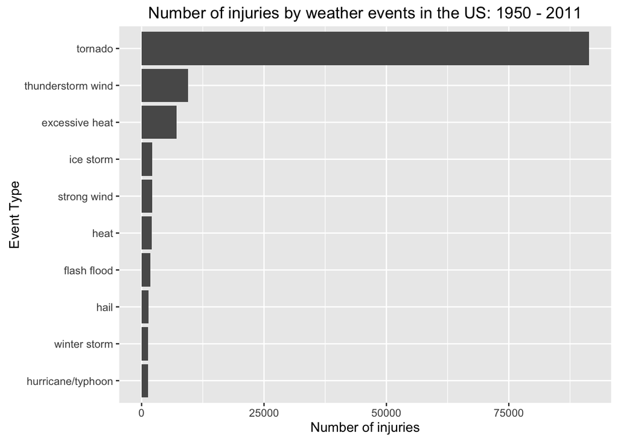

```r
ggplot(data = topinj, aes(x = reorder(EVTYPE, INJURIES), y = INJURIES)) + geom_bar(stat = "identity") +
  coord_flip() + xlab("Event Type") + ylab("Number of injuries") + ggtitle("Number of injuries by weather events in the US: 1950 - 2011")
```

Plotted the top 10 weather events causing fatalities using ggplot2.

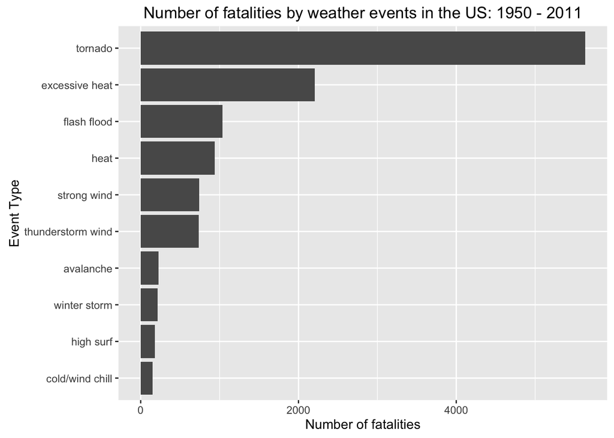

```r
ggplot(data = topfatal, aes(x = reorder(EVTYPE, FATALITIES), y = FATALITIES)) + geom_bar(stat = "identity") +
  coord_flip() + xlab("Event Type") + ylab("Number of fatalities") + ggtitle("Number of fatalities by weather events in the US: 1950 - 2011")
```

As seen in the figures above, tornadoes had the biggest impact on public health with the greatest number of fatalities and injuries. Between 1950 and 2011, tornado caused 5,633 fatalities and 91,364 injuries. Counts of fatalities and injuries for the top 10 weather events are available in the tables below.

```r
print(topfatal)
```

```
##               EVTYPE FATALITIES
## 33           tornado       5633
## 11    excessive heat       2206
## 12       flash flood       1036
## 18              heat        937
## 31       strong wind        740
## 32 thunderstorm wind        735
## 2          avalanche        225
## 38      winter storm        217
## 20         high surf        179
## 5    cold/wind chill        148
```

```r
print(topinj)
```

```
##               EVTYPE INJURIES
## 33           tornado    91364
## 32 thunderstorm wind     9510
## 11    excessive heat     7126
## 23         ice storm     2206
## 31       strong wind     2135
## 18              heat     2100
## 12       flash flood     1802
## 17              hail     1371
## 38      winter storm     1353
## 22 hurricane/typhoon     1333
```

## 2. Across the United States, which types of events have the greatest economic consequences?

Plotted property and crop damage amounts for the top 5 weather events with the greatest amount of damages (property and crop, combined) using ggplot2

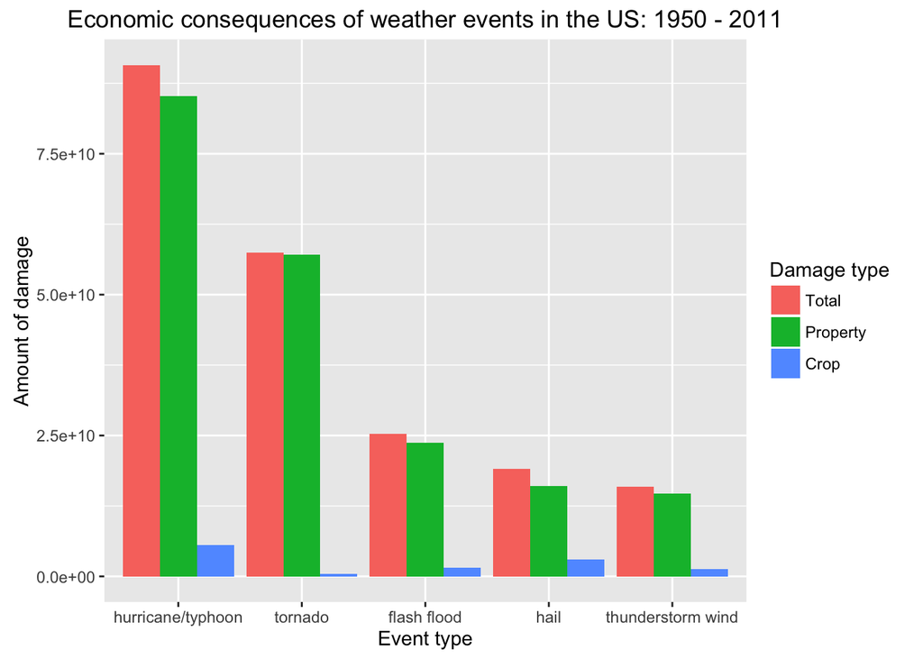

```r
ggplot(data = alldmg, aes(x = reorder(EVTYPE, -value), y = value, fill = variable)) +
  geom_bar(stat = "identity", position = "dodge") + xlab("Event type") +
  ylab("Amount of damage") + ggtitle("Economic consequences of weather events in the US: 1950 - 2011") +
  scale_fill_discrete(name="Damage type", labels = c("Total", "Property", "Crop"))
```

```r
propdmg <- propdmg[order(-propdmg$PROPDMGAMT),]
propdmg[1:10,]
```

```
##               EVTYPE  PROPDMGAMT
## 22 hurricane/typhoon 85256410010
## 33           tornado 57044133518
## 12       flash flood 23726219512
## 17              hail 16004566634
## 32 thunderstorm wind 14656711488
## 34    tropical storm  7714390550
## 38      winter storm  6748997260
## 31       strong wind  6314651453
## 30  storm surge/tide  4641188000
## 23         ice storm  3946232810
```

```r
cropdmg <- cropdmg[order(-cropdmg$CROPDMGAMT),]
cropdmg[1:10,]
```

```
##               EVTYPE  CROPDMGAMT
## 9            drought 13972621780
## 22 hurricane/typhoon  5506117800
## 23         ice storm  5022114300
## 17              hail  3046887803
## 31       strong wind  2120500900
## 15      frost/freeze  1997061000
## 12       flash flood  1532197150
## 32 thunderstorm wind  1274159708
## 19        heavy rain   946662800
## 34    tropical storm   694896000
```

**NOTE:** Property and crop damage amounts should be considered a broad estimate as the National Weather Service makes these estimates using all available data at the time of publication.